# Welcome To Our Graduation Project

### Dataset Overview

The **Framingham Heart Study** is considering a turning point in identifying the **risk factors of heart disease**, and is one of the most important epidemiological studies conducted. A lot of our present understanding of cardiovascular disease can be attributed to this study.

To better understand heart disease and the measures that could be taken to combat it, the Framingham Heart Study (FHS) was established in the late 1940's. It was a **joint project of Boston University and the National Heart, Lung, and Blood Institute (NHLBI)**.

The **aim** of the study was to to **better understand cardiovascular disease by enrolling people free of the disease, and see who**

**developed the disease in the next 10 years.**

| Column | Description |
| --- | --- |
| Gender | Male or female |
| Age | Age of the patient |
| Current Smoker | Whether or not the patient is a current smoker |
| Cigs Per Day | The number of cigarettes that the person smoked on average in one day |
| BP Meds | Whether or not the patient was on blood pressure medication |
| Prevalent Stroke | Whether or not the patient had previously had a stroke |
| Prevalent Hyp | Whether or not the patient was hypertensive |
| Diabetes | Whether or not the patient had diabetes |
| Tot Chol | Total cholesterol level |
| Sys BP | Systolic blood pressure |
| Dia BP | Diastolic blood pressure |
| BMI | Body Mass Index |
| Heart Rate | Heart rate |
| Glucose | Glucose level |
| TenYearCHD | indicates whether the patient has a 10-year risk of coronary heart disease (CHD) (Binary: "1" means "Yes", "0" means "No") |

### Libraries & Loading the Data

```python
import numpy as np
import pandas as pd
import matplotlib
import matplotlib.pyplot as plt
import seaborn as sns
import plotly.express as px
from scipy import stats
```

```python
df = pd.read_csv(r"C:\Users\user\Desktop\Framingham heart study dataset.csv")
```

# Exploratory Data Analysis

```python
print(f'No. of records are {df.shape[0]}')
print(f'No. of columns are {df.shape[1]}')
```

```
No. of records are 4238
No. of columns are 16
```

```python
df.head().T
```

|  | 0 | 1 | 2 | 3 | 4 |
| --- | --- | --- | --- | --- | --- |
| gender | 1.00 | 0.00 | 1.00 | 0.00 | 0.0 |
| age | 39.00 | 46.00 | 48.00 | 61.00 | 46.0 |
| education | 4.00 | 2.00 | 1.00 | 3.00 | 3.0 |
| currentSmoker | 0.00 | 0.00 | 1.00 | 1.00 | 1.0 |
| cigsPerDay | 0.00 | 0.00 | 20.00 | 30.00 | 23.0 |
| BPMeds | 0.00 | 0.00 | 0.00 | 0.00 | 0.0 |
| prevalentStroke | 0.00 | 0.00 | 0.00 | 0.00 | 0.0 |
| prevalentHyp | 0.00 | 0.00 | 0.00 | 1.00 | 0.0 |
| diabetes | 0.00 | 0.00 | 0.00 | 0.00 | 0.0 |
| totChol | 195.00 | 250.00 | 245.00 | 225.00 | 285.0 |
| sysBP | 106.00 | 121.00 | 127.50 | 150.00 | 130.0 |
| diaBP | 70.00 | 81.00 | 80.00 | 95.00 | 84.0 |
| BMI | 26.97 | 28.73 | 25.34 | 28.58 | 23.1 |
| heartRate | 80.00 | 95.00 | 75.00 | 65.00 | 85.0 |
| glucose | 77.00 | 76.00 | 70.00 | 103.00 | 85.0 |
| TenYearCHD | 0.00 | 0.00 | 0.00 | 1.00 | 0.0 |

```python
column = list(df.columns)
categorical_features = []
discrete_features = []

for i in column:
    if len(df[i].unique()) > 6:
        discrete_features.append(i)
    else:
        categorical_features.append(i)

print('Categorical Features :',*categorical_features)
print('Discrete Features :',*discrete_features)
```

```
Categorical Features : gender education currentSmoker BPMeds prevalentStroke prevalentHyp diabetes TenYearCHD
Discrete Features : age cigsPerDay totChol sysBP diaBP BMI heartRate glucose
```

```python
df.info()
```

```
<class 'pandas.core.frame.DataFrame'>
RangeIndex: 4238 entries, 0 to 4237
Data columns (total 16 columns):
 #   Column           Non-Null Count  Dtype
---  ------           --------------  -----
 0   gender           4238 non-null   int64
 1   age              4238 non-null   int64
 2   education        4133 non-null   float64
 3   currentSmoker    4238 non-null   int64
 4   cigsPerDay       4209 non-null   float64
 5   BPMeds           4185 non-null   float64
 6   prevalentStroke  4238 non-null   int64
 7   prevalentHyp     4238 non-null   int64
 8   diabetes         4238 non-null   int64
 9   totChol          4188 non-null   float64
 10  sysBP            4238 non-null   float64
 11  diaBP            4238 non-null   float64
 12  BMI              4219 non-null   float64
 13  heartRate        4237 non-null   float64
 14  glucose          3850 non-null   float64
 15  TenYearCHD       4238 non-null   int64
dtypes: float64(9), int64(7)
memory usage: 529.9 KB
```

```python
round(df.describe(), 2).T
```

|  | count | mean | std | min | 25% | 50% | 75% | max |
| --- | --- | --- | --- | --- | --- | --- | --- | --- |
| gender | 4238.0 | 0.43 | 0.50 | 0.00 | 0.00 | 0.0 | 1.00 | 1.0 |
| age | 4238.0 | 49.58 | 8.57 | 32.00 | 42.00 | 49.0 | 56.00 | 70.0 |
| education | 4133.0 | 1.98 | 1.02 | 1.00 | 1.00 | 2.0 | 3.00 | 4.0 |
| currentSmoker | 4238.0 | 0.49 | 0.50 | 0.00 | 0.00 | 0.0 | 1.00 | 1.0 |
| cigsPerDay | 4209.0 | 9.00 | 11.92 | 0.00 | 0.00 | 0.0 | 20.00 | 70.0 |
| BPMeds | 4185.0 | 0.03 | 0.17 | 0.00 | 0.00 | 0.0 | 0.00 | 1.0 |
| prevalentStroke | 4238.0 | 0.01 | 0.08 | 0.00 | 0.00 | 0.0 | 0.00 | 1.0 |
| prevalentHyp | 4238.0 | 0.31 | 0.46 | 0.00 | 0.00 | 0.0 | 1.00 | 1.0 |
| diabetes | 4238.0 | 0.03 | 0.16 | 0.00 | 0.00 | 0.0 | 0.00 | 1.0 |
| totChol | 4188.0 | 236.72 | 44.59 | 107.00 | 206.00 | 234.0 | 263.00 | 696.0 |
| sysBP | 4238.0 | 132.35 | 22.04 | 83.50 | 117.00 | 128.0 | 144.00 | 295.0 |
| diaBP | 4238.0 | 82.89 | 11.91 | 48.00 | 75.00 | 82.0 | 89.88 | 142.5 |
| BMI | 4219.0 | 25.80 | 4.08 | 15.54 | 23.07 | 25.4 | 28.04 | 56.8 |
| heartRate | 4237.0 | 75.88 | 12.03 | 44.00 | 68.00 | 75.0 | 83.00 | 143.0 |
| glucose | 3850.0 | 81.97 | 23.96 | 40.00 | 71.00 | 78.0 | 87.00 | 394.0 |
| TenYearCHD | 4238.0 | 0.15 | 0.36 | 0.00 | 0.00 | 0.0 | 0.00 | 1.0 |

```python
# Remove duplicates if any
df.drop_duplicates(inplace=True)
```

### Palette Style

Through our notebook we will focus on **data storytelling** to convey most of the information in terms of simple plots rather with complex analysis. Our main objective to **perform explinatory data analysis side by side with exploratory data analysis to present better insights for the interested audience and stakeholders** . All the plots made are as simple as possible with no interactivity and complecations. For the whole visualization a **custom color palette** shown below.

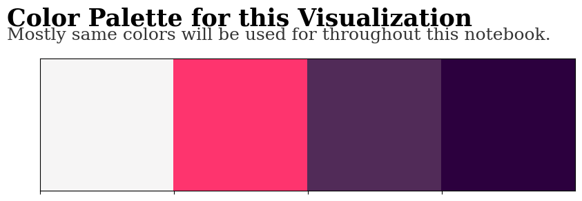

```python
# color palette for visualizations
colors = ['#f6f5f5','#fe346e','#512b58','#2c003e']
palette = sns.color_palette( palette = colors)

sns.palplot(palette, size =2.5)
plt.text(-0.75,-0.75,'Color Palette for this Visualization', {'font':'serif', 'size':25, 'weight':'bold'})
plt.text(-0.75,-0.64,'Mostly same colors will be used for throughout this notebook.', {'font':'serif', 'size':18, 'weight':'normal'}, alpha = 0.8)
plt.show()
```

### Handling Missing Values

```python
df.isnull().sum()
```

```
gender               0
age                  0
education          105
currentSmoker        0
cigsPerDay          29
BPMeds              53
prevalentStroke      0
prevalentHyp         0
diabetes             0
totChol             50
sysBP                0
diaBP                0
BMI                 19
heartRate            1
glucose            388
TenYearCHD           0
dtype: int64
```

### Visualization of Nullity of the Dataset

```python
import missingno as msno

color = ['grey','grey','grey','grey','grey','grey','grey','grey','grey','grey','#fe346e','#fe346e', '#fe346e', '#fe346e', '#fe346e', '#fe346e']
fig, ax = plt.subplots(figsize = (12,4), dpi = 70)
fig.patch.set_facecolor('#f6f5f5')
ax.set_facecolor('#f6f5f5')

msno.bar(df, sort = 'descending',
         color = color,
         ax = ax, fontsize =8,
         labels = 'off', filter = 'top')

ax.text(-1,1.35,'Visualization of Nullity of The Dataset',{'font': 'serif', 'size': 24,  'color':'black'},alpha = 0.9)
ax.text(-1,1.2,'Overall there are 4238 datapoints are present in \nthe given dataset. some features have null values.',{'font': 'serif', 'size': 12,  'color':'black'}, alpha = 0.7)

ax.set_xticklabels(ax.get_xticklabels(),rotation = 90,
                   ha = 'center', **{'font': 'serif', 'size': 14,'weight':'normal','color':'#512b58'}, alpha = 1)
ax.set_yticklabels('')
ax.spines['bottom'].set_visible(True)

plt.show()
```

[output not shown]

**How can we deal with blanks in our data?**

There are many ways. One can simply drop these records, fill the blanks with the mean, the median, or even simply the record before or after the missing value.

But there are other, more unusual ways.

Here We will use a **Decision Tree to predict the missing values**

```python
def fill_missing_continuous_values(df, missing_feature, feature_list):
    from sklearn.pipeline import Pipeline
    from sklearn.preprocessing import StandardScaler
    from sklearn.tree import DecisionTreeRegressor

    DT_pipe = Pipeline(steps=[
                               ('scale', StandardScaler()),
                               ('dt', DecisionTreeRegressor(random_state=42))
                              ])

    X = df[feature_list + [missing_feature]].copy()

    Missing = X[X[missing_feature].isna()]
    X = X[~X[missing_feature].isna()]
    Y = X.pop(missing_feature)

    DT_pipe.fit(X, Y)
    predicted_values = pd.Series(DT_pipe.predict(Missing[feature_list]), index=Missing.index)

    df.loc[Missing.index, missing_feature] = predicted_values
```

Now we can easily use the custom function we have built to fill the missing values of a feature by just a line of code

```python
fill_missing_continuous_values(df, 'BMI', ['age', 'gender'])
```

```python
fill_missing_continuous_values(df, 'cigsPerDay', ['currentSmoker', 'age', 'gender'])
```

```python
fill_missing_continuous_values(df, 'totChol', ['prevalentHyp', 'age', 'sysBP', 'diaBP'])
```

With the same way we will built a custom function to fill the missing values for the **categorical features** using a **Decision Tree Classifier**

```python
def fill_missing_categorical_values(df, missing_feature, feature_list):
    from sklearn.pipeline import Pipeline
    from sklearn.preprocessing import StandardScaler
    from sklearn.tree import DecisionTreeClassifier

    DT_pipe = Pipeline(steps=[
                               ('scale', StandardScaler()),
                               ('dt', DecisionTreeClassifier(random_state=42))
                              ])

    X = df[feature_list + [missing_feature]].copy()

    Missing = X[X[missing_feature].isna()]
    X = X[~X[missing_feature].isna()]
    Y = X.pop(missing_feature)

    DT_pipe.fit(X, Y)
    predicted_values = pd.Series(DT_pipe.predict(Missing[feature_list]), index=Missing.index)

    df.loc[Missing.index, missing_feature] = predicted_values
```

Now easily let's use it for filling the missing values of categorical features

```python
fill_missing_categorical_values(df, 'BPMeds', ['prevalentHyp', 'sysBP', 'diaBP'])
```

for the other features let's simply use the median/mode of the feature to fill the missing values of it

```python
# Calculate the median glucose level for each group (diabetes = 1 and diabetes = 0)
# fill missing glucose values with the appropriate group median
df['glucose'].fillna(df.groupby('diabetes')['glucose'].transform('median'), inplace=True)
```

```python
# Calculate the mode of the 'education' column
education_mode = df['education'].mode()[0]

# Fill the missing values in the 'education' column with the mode
df['education'].fillna(education_mode, inplace=True)
```

```python
df['heartRate'] = df['heartRate'].fillna(df['heartRate'].median())
```

```python
df.isnull().sum()
```

```
gender             0
age                0
education          0
currentSmoker      0
cigsPerDay         0
BPMeds             0
prevalentStroke    0
prevalentHyp       0
diabetes           0
totChol            0
sysBP              0
diaBP              0
BMI                0
heartRate          0
glucose            0
TenYearCHD         0
dtype: int64
```

### Saving Processed Data to a File

```python
# saving the processed data into a csv file
df.to_csv("Framingham Heart Study_Processed_Data.csv",index=False)
```

Now we have **successfully imputed all the null values of our dataset** It is time for us to move to **explore and analyze our data to search for patterns and insights**

### Exploring the Target Variable

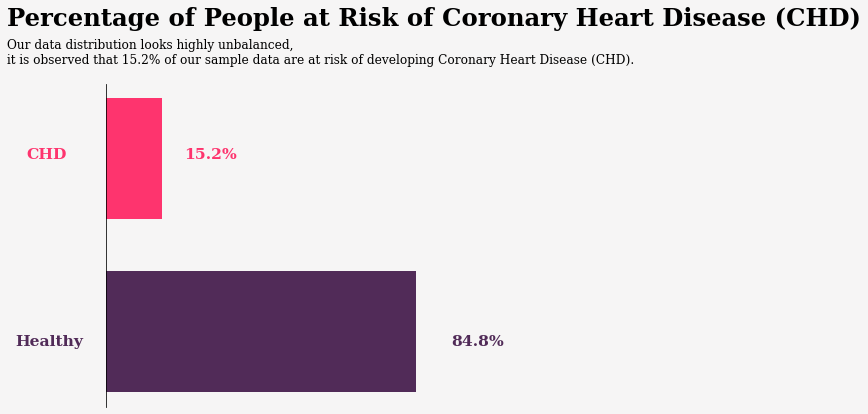

```python
# let us overview the distribution of the target of our data
x = pd.DataFrame(df.groupby(['TenYearCHD'])['TenYearCHD'].count())

# Plot
fig, ax = plt.subplots(figsize=(6, 6), dpi=70)
ax.barh([1], x.TenYearCHD[1], height=0.7, color='#fe346e')
plt.text(-1050, -0.08, 'Healthy', {'font': 'Serif', 'weight': 'bold', 'size': '16', 'style': 'normal', 'color': '#512b58'})
plt.text(4000, -0.08, '84.8%', {'font': 'Serif', 'weight': 'bold', 'size': '16', 'color': '#512b58'})
ax.barh([0], x.TenYearCHD[0], height=0.7, color='#512b58')
plt.text(-930, 1, 'CHD', {'font': 'Serif', 'weight': 'bold', 'size': '16', 'style': 'normal', 'color': '#fe346e'})
plt.text(900, 1, '15.2%', {'font': 'Serif', 'weight': 'bold', 'size': '16', 'color': '#fe346e'})

fig.patch.set_facecolor('#f6f5f5')
ax.set_facecolor('#f6f5f5')

plt.text(-1150, 1.77, 'Percentage of People at Risk of Coronary Heart Disease (CHD)', {'font': 'Serif', 'size': '25', 'weight': 'bold', 'color': 'black'})
plt.text(-1150, 1.55, 'Our data distribution looks highly unbalanced,\nit is observed that 15.2% of our sample data are at risk of developing Coronary Heart Disease (CHD).',
         {'font': 'Serif', 'size': '12.5', 'color': 'black'})

ax.axes.get_xaxis().set_visible(False)
ax.axes.get_yaxis().set_visible(False)
ax.spines['bottom'].set_visible(False)
ax.spines['left'].set_visible(True)
ax.spines['right'].set_visible(False)
ax.spines['top'].set_visible(False)

plt.show()
```

From distribution it is clear that **only every 15 people out of 100 people have develpoed CHD from our sampling data**. So this this appears as a highly **unbalanced data distribution**, and null accuracy score of this distribution it self is 85%, whcih imploys any dump model should randomly predictions of stroke could reach accuracy of 85%. So, while modeling and training data, **over sampling and under sampling** have to be done to obtain good and reliable results.

### Univariate Analysis of Continuous Variables

Since we will explore a variety of features, it is a good practice to automate the process by defining a **custom functions.**

### Feature Statistics Functions

```python
def explore_continuous_variable(feature, data=df):
    # Extract the column from the dataset
    column = data[feature]

    # Data type
    data_type = column.dtype

    # Basic statistics
    minimum = int(column.min())
    maximum = int(column.max())
    data_range = maximum - minimum
    mean = round(column.mean())
    median = int(column.median())
    q3 = int(column.quantile(0.75))
    q1 = int(column.quantile(0.25))
    iqr = q3 - q1
    variance = round(column.var(), 2)
    std_deviation = round(column.std(), 2)
    coefficient_of_variation = round(np.sqrt(variance) / mean, 2)
    skewness = round(column.skew(), 2)

    # Percentiles
    percentiles = column.describe(percentiles=[0.1, 0.25, 0.5, 0.75, 0.9])

    # Number of null values
    num_null_values = column.isnull().sum()

    # Calculate outliers based on IQR
    lower_bound = q1 - 1.5 * iqr
    upper_bound = q3 + 1.5 * iqr
    outliers_percentage = round(((column < lower_bound) | (column > upper_bound)).mean() * 100, 2)

    # Create a DataFrame to store the results
    results_df = pd.DataFrame({
        'Statistics': ['Feature', 'Data Type', 'Minimum Value', 'Maximum Value', 'Range', 'Mean', 'Median', 'Q3', 'Q1',
                       'IQR', 'Outliers Percentage', 'Variance', 'Standard Deviation', 'Coefficient of Variation', 'Skewness',
                       '10th Percentile', '25th Percentile', '50th Percentile', '75th Percentile', '90th Percentile',
                       'Number of Null Values'],
        'Values': [feature, data_type, minimum, maximum, data_range, mean, median, q3, q1, iqr, outliers_percentage, variance, std_deviation,
                   coefficient_of_variation, skewness, int(percentiles['10%']), int(percentiles['25%']),
                   int(percentiles['50%']), int(percentiles['75%']), int(percentiles['90%']), num_null_values
                   ]
    })

    results_df = results_df.reset_index(drop=True)

    # Create a Styler object
    styled_df = results_df.style.set_properties(**{'text-align': 'center'})

    return styled_df
```

```python
def compare_feature_statistics(feature, data=df):
    # Extract the column for CHD and Healthy individuals
    chd_column = data[data['TenYearCHD'] == 1][feature]
    healthy_column = data[data['TenYearCHD'] == 0][feature]

    # Basic statistics for CHD
    chd_mean = int(chd_column.mean())
    chd_median = int(chd_column.median())
    chd_std_deviation = round(chd_column.std(), 2)
    chd_min = int(chd_column.min())
    chd_max = int(chd_column.max())
    chd_iqr = int(chd_column.quantile(0.75) - chd_column.quantile(0.25))

    # Basic statistics for Healthy
    healthy_mean = int(healthy_column.mean())
    healthy_median = int(healthy_column.median())
    healthy_std_deviation = round(healthy_column.std(), 2)
    healthy_min = int(healthy_column.min())
    healthy_max = int(healthy_column.max())
    healthy_iqr = int(healthy_column.quantile(0.75) - healthy_column.quantile(0.25))

    # Create a DataFrame to store the results
    results_df = pd.DataFrame({
        'Statistics': ['Mean', 'Median', 'Std Deviation', 'Min', 'Max', 'IQR'],
        'CHD': [chd_mean, chd_median, chd_std_deviation, chd_min, chd_max, chd_iqr],
        'Healthy': [healthy_mean, healthy_median, healthy_std_deviation, healthy_min, healthy_max, healthy_iqr]
    })

    results_df = results_df.set_index('Statistics')

    results_df = results_df.astype(int)

    # Create a Styler object
    styled_df = results_df.style.set_properties(**{'text-align': 'center'})

    return styled_df
```

### Distribution Viz Functions

```python
def plot_distribution(df, feature, plot_title):
    with plt.style.context('fivethirtyeight'):
        fig, ax = plt.subplots(1, 2, figsize=(20, 5))

        # Histogram
        sns.histplot(x=feature,
                     data=df,
                     ax=ax[0],
                     linewidth=0.8,
                     color='#512b58',
                     bins=20).set_title(f"Distribution of {plot_title}")
        ax[0].set_xlabel(plot_title)

        # Box plot for the entire distribution
        sns.boxplot(x=feature,
                    data=df,
                    linewidth=1.5,
                    width=0.5,
                    color='#512b58',
                    ax=ax[1]).set_title(f"Box Plot of {plot_title}")
        ax[1].set_xlabel(plot_title)

        plt.show()
```

```python
df['TenYearCHD_statue'] = df['TenYearCHD'].map({1: 'CHD', 0: 'Healthy'})
def plot_CHD_vs_Healthy(feature, plot_title, df = df):
    box_plots_colors = {'Healthy': '#3081D0', 'CHD':'#fe346e'}

    with plt.style.context('fivethirtyeight'):
        fig, ax = plt.subplots(1, 2, figsize=(20, 5))

        # KDE plot for CHD vs Healthy
        sns.kdeplot(data=df[df['TenYearCHD_statue']=='CHD'], x=feature, color='#fe346e', fill=True, linewidth=1.5, ec='black', alpha=0.8, zorder=3, ax=ax[0])
        sns.kdeplot(data=df[df['TenYearCHD_statue']=='Healthy'], x=feature, color='#3081D0', fill=True, linewidth=1.5, ec='black', alpha=0.8, zorder=3, ax=ax[0])

        ax[0].set_title(f"KDE Plot of {plot_title} by CHD")
        ax[0].set_xlabel(plot_title)
        ax[0].set_ylabel('Density')

        # Box plot for CHD vs Healthy
        sns.boxplot(x=feature,
                    data=df,
                    y="TenYearCHD_statue",
                    linewidth=1.5,
                    palette=box_plots_colors,
                    ax=ax[1]).set_title(f"Distribution of {plot_title} by CHD")
        ax[1].set_xlabel(plot_title)
        ax[1].set_ylabel('10 years CHD Status')

        plt.show()
```

### Age

```python
explore_continuous_variable('age')
```

|  | Statistics | Values |
| --- | --- | --- |
| 0 | Feature | age |
| 1 | Data Type | int64 |
| 2 | Minimum Value | 32 |
| 3 | Maximum Value | 70 |
| 4 | Range | 38 |
| 5 | Mean | 50 |
| 6 | Median | 49 |
| 7 | Q3 | 56 |
| 8 | Q1 | 42 |
| 9 | IQR | 14 |
| 10 | Outliers Percentage | 0.000000 |
| 11 | Variance | 73.480000 |
| 12 | Standard Deviation | 8.570000 |
| 13 | Coefficient of Variation | 0.170000 |
| 14 | Skewness | 0.230000 |
| 15 | 10th Percentile | 39 |
| 16 | 25th Percentile | 42 |
| 17 | 50th Percentile | 49 |
| 18 | 75th Percentile | 56 |
| 19 | 90th Percentile | 62 |
| 20 | Number of Null Values | 0 |

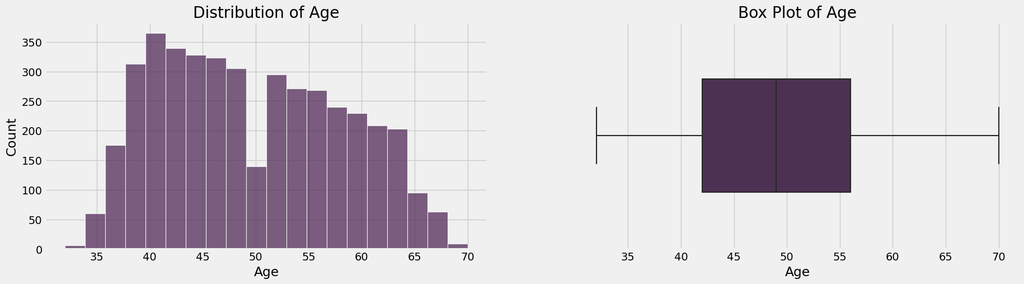

```python
plot_distribution(df, 'age', 'Age')
```

```python
compare_feature_statistics('age')
```

| Statistics | CHD | Healthy |
| --- | --- | --- |
| Mean | 54 | 48 |
| Median | 55 | 48 |
| Std Deviation | 8 | 8 |
| Min | 35 | 32 |
| Max | 70 | 70 |
| IQR | 13 | 13 |

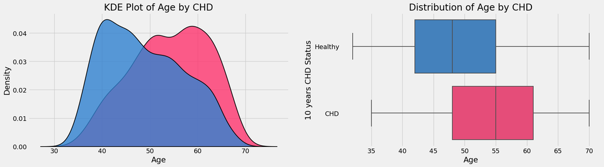

```python
plot_CHD_vs_Healthy("age", "Age")
```

### Glucose

```python
explore_continuous_variable('glucose')
```

|  | Statistics | Values |
| --- | --- | --- |
| 0 | Feature | glucose |
| 1 | Data Type | float64 |
| 2 | Minimum Value | 40 |
| 3 | Maximum Value | 394 |
| 4 | Range | 354 |
| 5 | Mean | 82 |
| 6 | Median | 78 |
| 7 | Q3 | 85 |
| 8 | Q1 | 72 |
| 9 | IQR | 13 |
| 10 | Outliers Percentage | 6.280000 |
| 11 | Variance | 526.600000 |
| 12 | Standard Deviation | 22.950000 |
| 13 | Coefficient of Variation | 0.280000 |
| 14 | Skewness | 6.480000 |
| 15 | 10th Percentile | 66 |
| 16 | 25th Percentile | 72 |
| 17 | 50th Percentile | 78 |
| 18 | 75th Percentile | 85 |
| 19 | 90th Percentile | 97 |
| 20 | Number of Null Values | 0 |

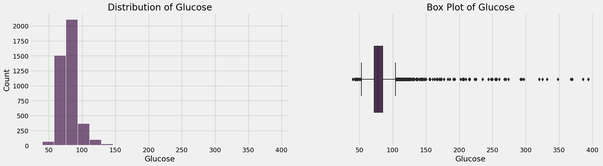

```python
plot_distribution(df, "glucose", "Glucose")
```

```python
compare_feature_statistics('glucose')
```

| Statistics | CHD | Healthy |
| --- | --- | --- |
| Mean | 88 | 80 |
| Median | 78 | 78 |
| Std Deviation | 39 | 18 |
| Min | 40 | 40 |
| Max | 394 | 386 |
| IQR | 16 | 13 |

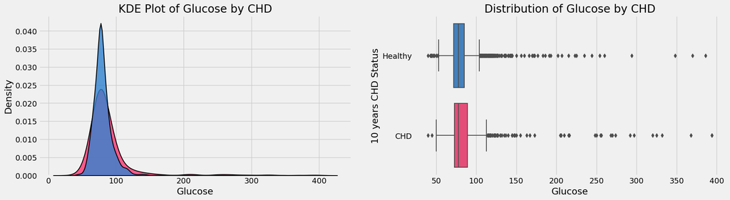

```python
plot_CHD_vs_Healthy("glucose", "Glucose")
```

### BMI

```python
explore_continuous_variable('BMI')
```

|  | Statistics | Values |
| --- | --- | --- |
| 0 | Feature | BMI |
| 1 | Data Type | float64 |
| 2 | Minimum Value | 15 |
| 3 | Maximum Value | 56 |
| 4 | Range | 41 |
| 5 | Mean | 26 |
| 6 | Median | 25 |
| 7 | Q3 | 28 |
| 8 | Q1 | 23 |
| 9 | IQR | 5 |
| 10 | Outliers Percentage | 2.270000 |
| 11 | Variance | 16.590000 |
| 12 | Standard Deviation | 4.070000 |
| 13 | Coefficient of Variation | 0.160000 |
| 14 | Skewness | 0.980000 |
| 15 | 10th Percentile | 21 |
| 16 | 25th Percentile | 23 |
| 17 | 50th Percentile | 25 |
| 18 | 75th Percentile | 28 |
| 19 | 90th Percentile | 30 |
| 20 | Number of Null Values | 0 |

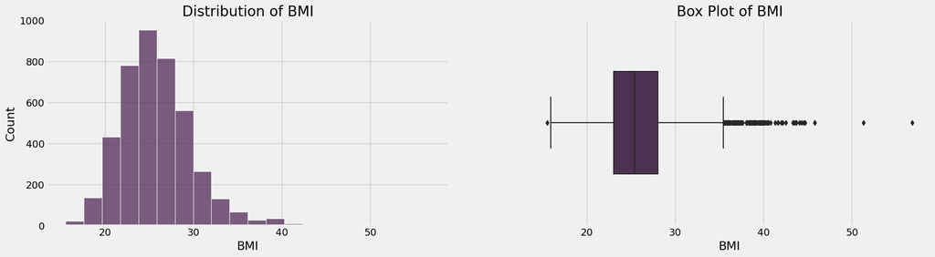

```python
plot_distribution(df, "BMI", "BMI")
```

```python
compare_feature_statistics('BMI')
```

| Statistics | CHD | Healthy |
| --- | --- | --- |
| Mean | 26 | 25 |
| Median | 26 | 25 |
| Std Deviation | 4 | 3 |
| Min | 15 | 15 |
| Max | 56 | 51 |
| IQR | 5 | 4 |

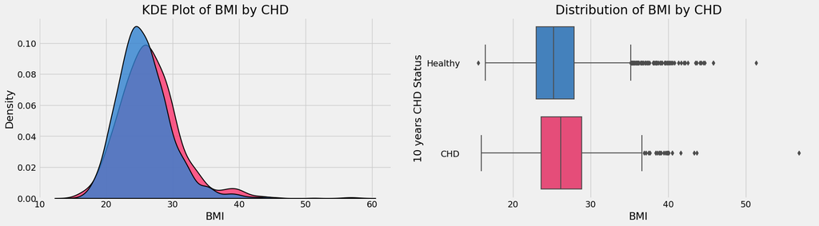

```python
plot_CHD_vs_Healthy("BMI", "BMI")
```

### Age, Glucose & BMI Insights

- **Age** is a **strong predictor of CHD**. The risk of developing CHD increases significantly with age. This is **likely due to the cumulative effects of aging on the heart and blood vessels.**
- **Glucose levels** are also a risk factor for CHD. People with high glucose levels are more likely to develop CHD than people with low glucose levels. This is **likely due to the fact that high glucose levels can damage the blood vessels and nerves that supply the heart.**
- **BMI** is also a risk factor for CHD. People with **high BMI are more likely to develop CHD than people with low BMI**. This is **likely due to the fact that people with high BMI are more likely to have other risk factors for CHD**, such as high blood pressure, high cholesterol levels, and diabetes.

### Total Cholesterol

```python
explore_continuous_variable('totChol')
```

|  | Statistics | Values |
| --- | --- | --- |
| 0 | Feature | totChol |
| 1 | Data Type | float64 |
| 2 | Minimum Value | 107 |
| 3 | Maximum Value | 696 |
| 4 | Range | 589 |
| 5 | Mean | 237 |
| 6 | Median | 234 |
| 7 | Q3 | 263 |
| 8 | Q1 | 206 |
| 9 | IQR | 57 |
| 10 | Outliers Percentage | 1.340000 |
| 11 | Variance | 1987.880000 |
| 12 | Standard Deviation | 44.590000 |
| 13 | Coefficient of Variation | 0.190000 |
| 14 | Skewness | 0.870000 |
| 15 | 10th Percentile | 183 |
| 16 | 25th Percentile | 206 |
| 17 | 50th Percentile | 234 |
| 18 | 75th Percentile | 263 |
| 19 | 90th Percentile | 292 |
| 20 | Number of Null Values | 0 |

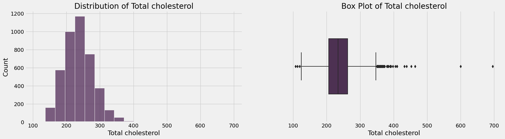

```python
plot_distribution(df, "totChol", "Total cholesterol")
```

```python
compare_feature_statistics('totChol')
```

| Statistics | CHD | Healthy |
| --- | --- | --- |
| Mean | 245 | 235 |
| Median | 241 | 232 |
| Std Deviation | 48 | 43 |
| Min | 107 | 113 |
| Max | 600 | 696 |
| IQR | 59 | 56 |

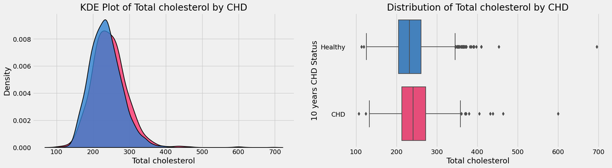

```python
plot_CHD_vs_Healthy("totChol", "Total cholesterol")
```

### Systolic Blood Pressure

```python
explore_continuous_variable('sysBP')
```

|  | Statistics | Values |
| --- | --- | --- |
| 0 | Feature | sysBP |
| 1 | Data Type | float64 |
| 2 | Minimum Value | 83 |
| 3 | Maximum Value | 295 |
| 4 | Range | 212 |
| 5 | Mean | 132 |
| 6 | Median | 128 |
| 7 | Q3 | 144 |
| 8 | Q1 | 117 |
| 9 | IQR | 27 |
| 10 | Outliers Percentage | 2.970000 |
| 11 | Variance | 485.680000 |
| 12 | Standard Deviation | 22.040000 |
| 13 | Coefficient of Variation | 0.170000 |
| 14 | Skewness | 1.150000 |
| 15 | 10th Percentile | 108 |
| 16 | 25th Percentile | 117 |
| 17 | 50th Percentile | 128 |
| 18 | 75th Percentile | 144 |
| 19 | 90th Percentile | 162 |
| 20 | Number of Null Values | 0 |

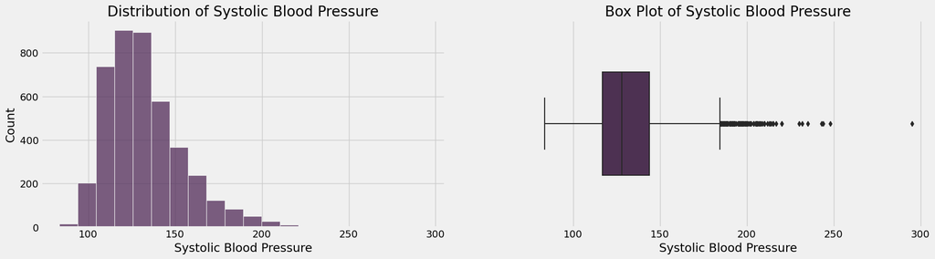

```python
plot_distribution(df, "sysBP", "Systolic Blood Pressure")
```

```python
compare_feature_statistics('sysBP')
```

| Statistics | CHD | Healthy |
| --- | --- | --- |
| Mean | 143 | 130 |
| Median | 139 | 127 |
| Std Deviation | 26 | 20 |
| Min | 83 | 83 |
| Max | 295 | 243 |
| IQR | 33 | 25 |

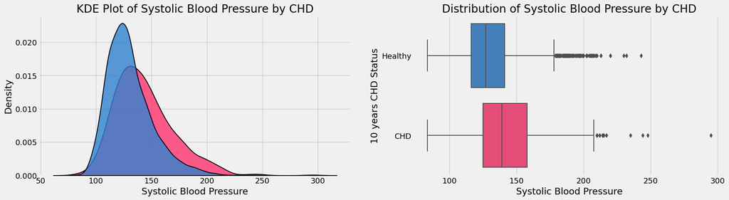

```python
plot_CHD_vs_Healthy("sysBP", "Systolic Blood Pressure")
```

### Diastolic Blood Pressure

```python
explore_continuous_variable('diaBP')
```

|  | Statistics | Values |
| --- | --- | --- |
| 0 | Feature | diaBP |
| 1 | Data Type | float64 |
| 2 | Minimum Value | 48 |
| 3 | Maximum Value | 142 |
| 4 | Range | 94 |
| 5 | Mean | 83 |
| 6 | Median | 82 |
| 7 | Q3 | 89 |
| 8 | Q1 | 75 |
| 9 | IQR | 14 |
| 10 | Outliers Percentage | 2.240000 |
| 11 | Variance | 141.870000 |
| 12 | Standard Deviation | 11.910000 |
| 13 | Coefficient of Variation | 0.140000 |
| 14 | Skewness | 0.710000 |
| 15 | 10th Percentile | 69 |
| 16 | 25th Percentile | 75 |
| 17 | 50th Percentile | 82 |
| 18 | 75th Percentile | 89 |
| 19 | 90th Percentile | 98 |
| 20 | Number of Null Values | 0 |

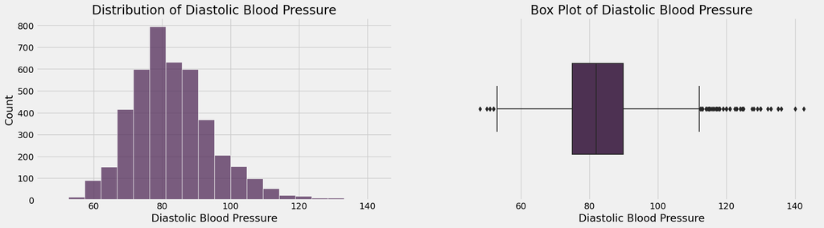

```python
plot_distribution(df, "diaBP", "Diastolic Blood Pressure")
```

```python
compare_feature_statistics('diaBP')
```

| Statistics | CHD | Healthy |
| --- | --- | --- |
| Mean | 86 | 82 |
| Median | 85 | 81 |
| Std Deviation | 14 | 11 |
| Min | 48 | 50 |
| Max | 140 | 142 |
| IQR | 17 | 14 |

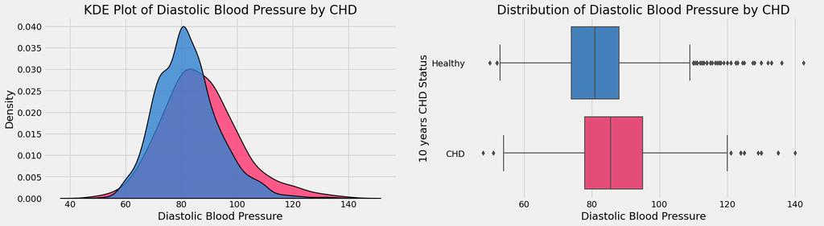

```python
plot_CHD_vs_Healthy("diaBP", "Diastolic Blood Pressure")
```

### Total Cholesterol & Blood Pressure Insights

Overall, these visualization shows that **people with CHD tend to have higher cholesterol and blood pressure levels than healthy people.**

### Heart Rate

```python
explore_continuous_variable('heartRate')
```

|  | Statistics | Values |
| --- | --- | --- |
| 0 | Feature | heartRate |
| 1 | Data Type | float64 |
| 2 | Minimum Value | 44 |
| 3 | Maximum Value | 143 |
| 4 | Range | 99 |
| 5 | Mean | 76 |
| 6 | Median | 75 |
| 7 | Q3 | 83 |
| 8 | Q1 | 68 |
| 9 | IQR | 15 |
| 10 | Outliers Percentage | 1.790000 |
| 11 | Variance | 144.610000 |
| 12 | Standard Deviation | 12.030000 |
| 13 | Coefficient of Variation | 0.160000 |
| 14 | Skewness | 0.640000 |
| 15 | 10th Percentile | 60 |
| 16 | 25th Percentile | 68 |
| 17 | 50th Percentile | 75 |
| 18 | 75th Percentile | 83 |
| 19 | 90th Percentile | 92 |
| 20 | Number of Null Values | 0 |

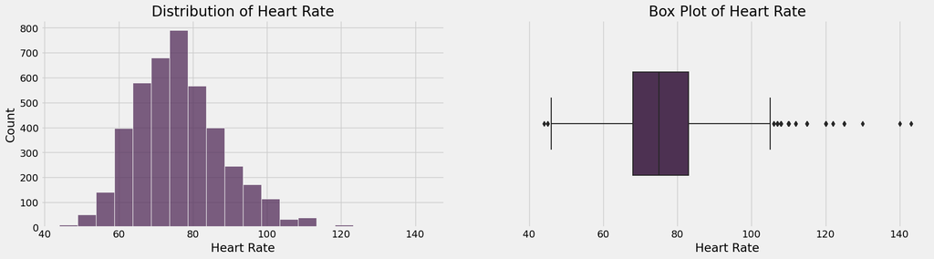

```python
plot_distribution(df, "heartRate", "Heart Rate")
```

```python
compare_feature_statistics('heartRate')
```

| Statistics | CHD | Healthy |
| --- | --- | --- |
| Mean | 76 | 75 |
| Median | 75 | 75 |
| Std Deviation | 12 | 11 |
| Min | 50 | 44 |
| Max | 120 | 143 |
| IQR | 17 | 15 |

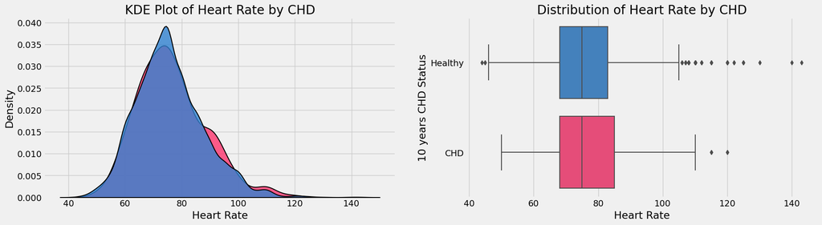

```python
plot_CHD_vs_Healthy("heartRate", "Heart Rate")
```

### Avg. Number of Cigarettes

```python
explore_continuous_variable('cigsPerDay')
```

|  | Statistics | Values |
| --- | --- | --- |
| 0 | Feature | cigsPerDay |
| 1 | Data Type | float64 |
| 2 | Minimum Value | 0 |
| 3 | Maximum Value | 70 |
| 4 | Range | 70 |
| 5 | Mean | 9 |
| 6 | Median | 0 |
| 7 | Q3 | 20 |
| 8 | Q1 | 0 |
| 9 | IQR | 20 |
| 10 | Outliers Percentage | 0.280000 |
| 11 | Variance | 141.770000 |
| 12 | Standard Deviation | 11.910000 |
| 13 | Coefficient of Variation | 1.320000 |
| 14 | Skewness | 1.230000 |
| 15 | 10th Percentile | 0 |
| 16 | 25th Percentile | 0 |
| 17 | 50th Percentile | 0 |
| 18 | 75th Percentile | 20 |
| 19 | 90th Percentile | 25 |
| 20 | Number of Null Values | 0 |

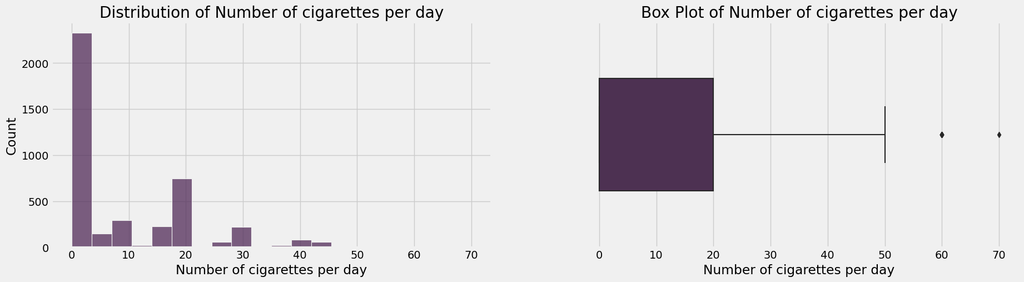

```python
plot_distribution(df, "cigsPerDay", "Number of cigarettes per day")
```

```python
compare_feature_statistics('cigsPerDay')
```

| Statistics | CHD | Healthy |
| --- | --- | --- |
| Mean | 10 | 8 |
| Median | 3 | 0 |
| Std Deviation | 12 | 11 |
| Min | 0 | 0 |
| Max | 60 | 70 |
| IQR | 20 | 20 |

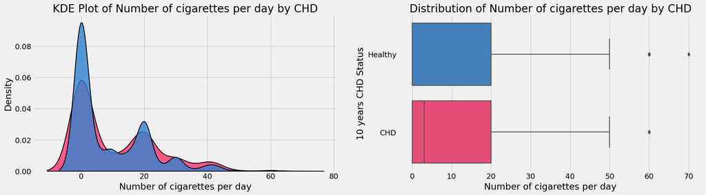

```python
plot_CHD_vs_Healthy("cigsPerDay", "Number of cigarettes per day")
```

### Heart Rate & Avg. Number of Cigarettes Insights

The charts show that people with CHD have a little bit higher average heart rate than people without CHD , it also shows that people who smoke more numbers of cigarettes tend to be more likely develop CHD .

### Outliers handling discussion

During our examination of the dataset, we observed the presence of outliers in various features, as indicated by statistical measures such as box plots and histograms we have built before. These outliers were defined as values that **exceeded the range of Q3 + 1.5 *IQR (interquartile range) or were below Q1 - 1.5* IQR**. However, we subsequently engaged in discussions with domain experts in the medical field to gain a deeper understanding of these outliers.

The insights provided by **medical domain experts** played a crucial role in our decision-making process. We learned that the outliers we initially identified actually represent valid and plausible data points that **can exist in the real world. These values are not errors or noise but rather reflect extreme occurrences** that can contribute to a comprehensive understanding of the factors associated with CHD.

Based on these discussions and the validation of the outliers, we have made the **informed decision to retain them in our analysis.**

By doing so, we aim to **capture the full range of real-world scenarios and avoid introducing bias into our findings.**

### Univariate analysis of discrete variables

### Distributions Quick Overview

```python
def explore_categorical_variable(feature, data = df):
    # Extract the column from the dataset
    column = data[feature]

    # Data type
    data_type = column.dtype

    # Count of each category
    category_counts = column.value_counts()

    # Percentage of each category
    category_percentages = column.value_counts(normalize=True) * 100

    # Mode (most frequent category)
    mode = column.mode().iloc[0]

    # Create a DataFrame to store the results
    results_df = pd.DataFrame({
        'Statistics': ['Data Type', 'Count', 'Percentage', 'Mode'],
        'Values': [data_type, category_counts, category_percentages, mode]
    })

    # Remove the index column
    results_df = results_df.reset_index(drop=True)

    return results_df
```

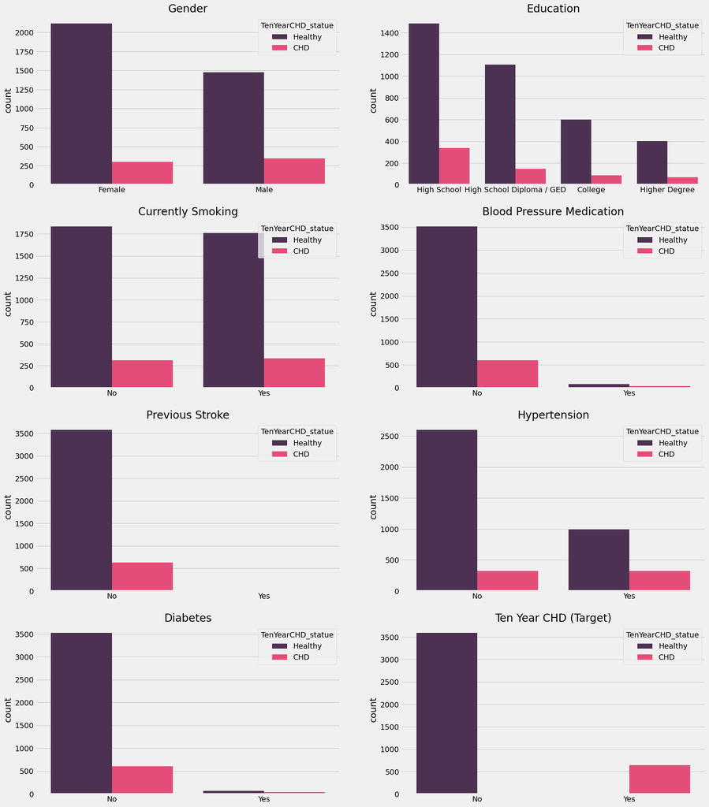

```python
with plt.style.context('fivethirtyeight'):


    plt.figure(figsize = (20,25))

    custom_palette = {'Healthy': '#512b58', 'CHD':'#fe346e'}

    plt.subplot(4,2,1)
    plt.gca().set_title('Gender')
    sns.countplot(x = df['gender'], hue=df['TenYearCHD_statue'], palette=custom_palette)
    plt.xticks([0, 1], ['Female', 'Male'])
    plt.gca().set_xlabel('')

    plt.subplot(4,2,2)
    plt.gca().set_title('Education')
    sns.countplot(x = df['education'], hue=df['TenYearCHD_statue'], palette=custom_palette)
    plt.xticks([0, 1, 2, 3], ['High School', 'High School Diploma / GED', 'College', 'Higher Degree'])
    plt.gca().set_xlabel('')

    plt.subplot(4,2,3)
    plt.gca().set_title('Currently Smoking')
    sns.countplot(x = df['currentSmoker'], hue=df['TenYearCHD_statue'], palette=custom_palette )
    plt.xticks([0, 1], ['No', 'Yes'])
    plt.gca().set_xlabel('')

    plt.subplot(4,2,4)
    plt.gca().set_title('Blood Pressure Medication')
    sns.countplot(x = df['BPMeds'], hue=df['TenYearCHD_statue'], palette=custom_palette )
    plt.xticks([0, 1], ['No', 'Yes'])
    plt.gca().set_xlabel('')

    plt.subplot(4,2,5)
    plt.gca().set_title('Previous Stroke')
    sns.countplot(x = df['prevalentStroke'], hue=df['TenYearCHD_statue'], palette=custom_palette )
    plt.xticks([0, 1], ['No', 'Yes'])
    plt.gca().set_xlabel('')

    plt.subplot(4,2,6)
    plt.gca().set_title('Hypertension')
    sns.countplot(x = df['prevalentHyp'], hue=df['TenYearCHD_statue'], palette=custom_palette )
    plt.xticks([0, 1], ['No', 'Yes'])
    plt.gca().set_xlabel('')

    plt.subplot(4,2,7)
    plt.gca().set_title('Diabetes')
    sns.countplot(x = df['diabetes'], hue=df['TenYearCHD_statue'], palette=custom_palette )
    plt.xticks([0, 1], ['No', 'Yes'])
    plt.gca().set_xlabel('')

    plt.subplot(4,2,8)
    plt.gca().set_title('Ten Year CHD (Target)')
    sns.countplot(x = df['TenYearCHD_statue'], hue=df['TenYearCHD_statue'], palette=custom_palette )
    plt.xticks([0, 1], ['No', 'Yes'])
    plt.gca().set_xlabel('')
```

Overview of the categorical features shows the value counts of the CHD and no CHD for each categorical feature . However since the data is unbalanced it is hard to extract insights from only the absloute values . visualizing and comparing **percentages** rather than raw counts can provide a clearer picture of the relationships within the data.

Since we will explore a variety of features, it is a good practice to automate the process by defining a **custom function.** Our function will visualize **2 pie charts categorized by CHD or healthy (one for the existance of the feature and other for not )**

```python
def plot_CHD_percentage(df, group_feature, title1, title2, overall_title):
    # Calculate percentage of people who developed CHD for each group
    grouped = df.groupby(group_feature)['TenYearCHD'].value_counts(normalize=True).rename('percentage').mul(100).reset_index()

    # Define custom color palette
    custom_palette = {0: '#512b58', 1: '#fe346e'}
    # Define custom x-axis labels
    x_labels = {0: f'Non-{group_feature.capitalize()}', 1: group_feature.capitalize()}
    # Define custom legend labels
    legend_labels = {0: 'Healthy', 1: 'CHD'}

    with plt.style.context('fivethirtyeight'):
        fig, ax = plt.subplots(1, 2, figsize=(15, 6))

        for i, group_status in enumerate(grouped[group_feature].unique()):
            data = grouped[grouped[group_feature] == group_status]
            wedges, texts, autotexts = ax[i].pie(data['percentage'], labels=[legend_labels[status] for status in data['TenYearCHD']],
                                                 colors=[custom_palette[status] for status in data['TenYearCHD']],
                                                 autopct='%1.1f%%')
            ax[i].set_title(title2 if i == 1 else title1)  # Use custom titles for each pie chart
            plt.setp(autotexts, size=16, color="w")
        fig.legend(wedges, legend_labels.values(), title="Ten Year CHD", loc="center right")

        fig.suptitle(f'Percentage of people who developed CHD within 10 years grouped by {overall_title} status', fontsize=18)
        plt.show()
```

### Gender

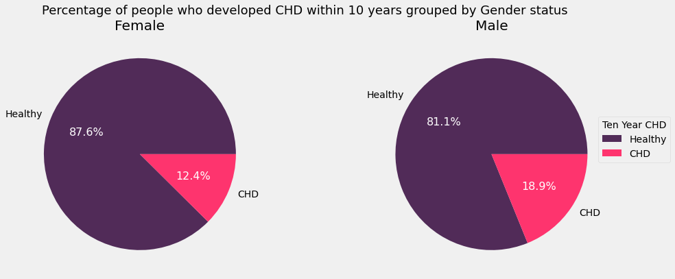

```python
plot_CHD_percentage(df, 'gender', 'Female', 'Male', 'Gender')
```

### Current Smoker

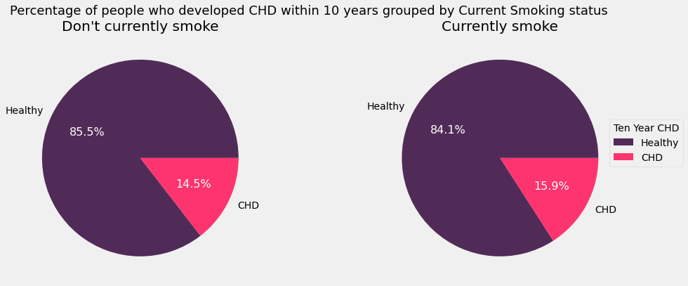

```python
plot_CHD_percentage(df, 'currentSmoker', "Don't currently smoke", 'Currently smoke', 'Current Smoking')
```

### Diabetes

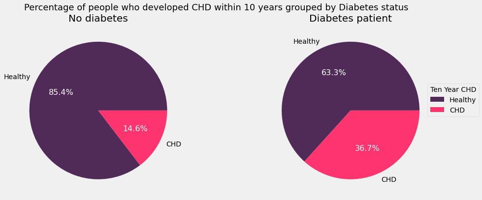

```python
plot_CHD_percentage(df,'diabetes', 'No diabetes', 'Diabetes patient', 'Diabetes')
```

### Blood Pressure Medication

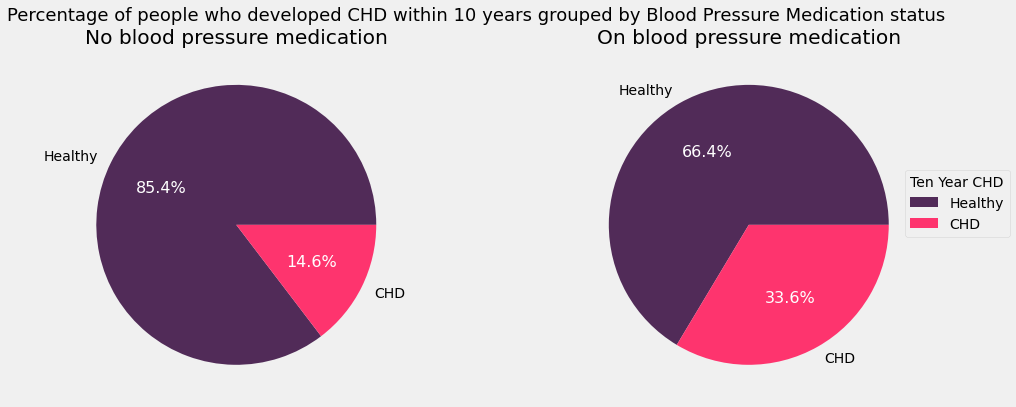

```python
plot_CHD_percentage(df, 'BPMeds', 'No blood pressure medication' , 'On blood pressure medication', 'Blood Pressure Medication')
```

### Prevalent Stroke

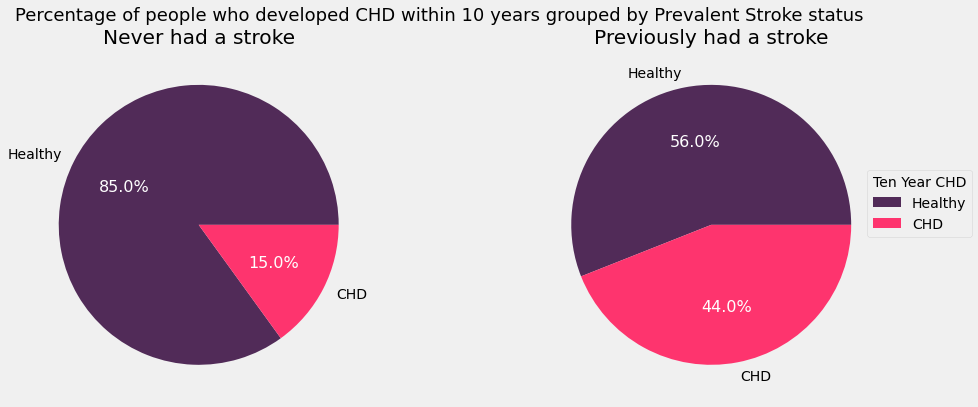

```python
plot_CHD_percentage(df, 'prevalentStroke', 'Never had a stroke', 'Previously had a stroke', 'Prevalent Stroke')
```

### Prevalent Hypertensive

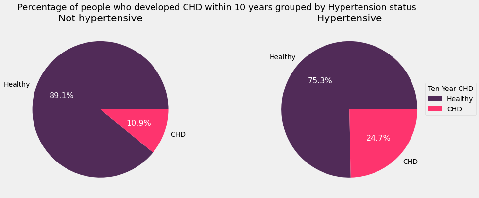

```python
plot_CHD_percentage(df, 'prevalentHyp', 'Not hypertensive', 'Hypertensive' ,  'Hypertension')
```

### Discrete Variables Insights

The visualizations that we have provided so far as part of our Univariate analysis of discrete variables show the pie charts that **shows the percentage of people who developed CHD within 10 years, grouped by the different features status,** here is some overall insights we have gained :

- people with diabetes are 2.5 times more likely to develop CHD within 10 years than people without diabetes.
- people who previously had a stroke are 3 times more likely to develop a CHD
- people who are hypertensive or on blood pressure medication are more likely to develop CHD
- viz shows people who are currently smoking have a slightly more probability to develop the disease

from this we can inform that it is highly recommended to those people who are at risk of developing the disease or even for those who are less likely to develop it to :

- Manage blood sugar levels.
- Control blood pressure.
- Quit smoking.
- Maintain a healthy lifestyle

#### Let's have an overall look of the Correlation between all of our features

```python
df = df.drop(['TenYearCHD_statue'], axis=1)
```

```python
df.corr()
```

|  | gender | age | education | currentSmoker | cigsPerDay | BPMeds | prevalentStroke | prevalentHyp | diabetes | totChol | sysBP | diaBP | BMI | heartRate | glucose | TenYearCHD |
| --- | --- | --- | --- | --- | --- | --- | --- | --- | --- | --- | --- | --- | --- | --- | --- | --- |
| gender | 1.000000 | -0.028979 | 0.013299 | 0.197596 | 0.319053 | -0.052554 | -0.004546 | 0.005313 | 0.015708 | -0.067260 | -0.035989 | 0.057933 | 0.081539 | -0.116621 | 0.009039 | 0.088428 |
| age | -0.028979 | 1.000000 | -0.164809 | -0.213748 | -0.192900 | 0.121691 | 0.057655 | 0.307194 | 0.101258 | 0.260887 | 0.394302 | 0.206104 | 0.137026 | -0.012848 | 0.116212 | 0.225256 |
| education | 0.013299 | -0.164809 | 1.000000 | 0.019403 | 0.010637 | -0.007309 | -0.032881 | -0.078807 | -0.038147 | -0.022272 | -0.126197 | -0.062732 | -0.140002 | -0.049588 | -0.033717 | -0.052812 |
| currentSmoker | 0.197596 | -0.213748 | 0.019403 | 1.000000 | 0.770223 | -0.049549 | -0.032988 | -0.103260 | -0.044295 | -0.046897 | -0.130230 | -0.107746 | -0.167147 | 0.062330 | -0.053568 | 0.019456 |
| cigsPerDay | 0.319053 | -0.192900 | 0.010637 | 0.770223 | 1.000000 | -0.047301 | -0.033014 | -0.067689 | -0.037785 | -0.025103 | -0.089546 | -0.057011 | -0.092286 | 0.075031 | -0.054026 | 0.056416 |
| BPMeds | -0.052554 | 0.121691 | -0.007309 | -0.049549 | -0.047301 | 1.000000 | 0.114056 | 0.259769 | 0.050968 | 0.080509 | 0.253604 | 0.195075 | 0.100172 | 0.016141 | 0.049030 | 0.089376 |
| prevalentStroke | -0.004546 | 0.057655 | -0.032881 | -0.032988 | -0.033014 | 0.114056 | 1.000000 | 0.074830 | 0.006949 | 0.000200 | 0.057009 | 0.045190 | 0.029774 | -0.017674 | 0.018442 | 0.061810 |
| prevalentHyp | 0.005313 | 0.307194 | -0.078807 | -0.103260 | -0.067689 | 0.259769 | 0.074830 | 1.000000 | 0.077808 | 0.162254 | 0.696755 | 0.615751 | 0.301579 | 0.147196 | 0.082910 | 0.177603 |
| diabetes | 0.015708 | 0.101258 | -0.038147 | -0.044295 | -0.037785 | 0.050968 | 0.006949 | 0.077808 | 1.000000 | 0.038980 | 0.111283 | 0.050329 | 0.086060 | 0.048996 | 0.621276 | 0.097317 |
| totChol | -0.067260 | 0.260887 | -0.022272 | -0.046897 | -0.025103 | 0.080509 | 0.000200 | 0.162254 | 0.038980 | 1.000000 | 0.208279 | 0.164544 | 0.112171 | 0.090112 | 0.043744 | 0.081597 |
| sysBP | -0.035989 | 0.394302 | -0.126197 | -0.130230 | -0.089546 | 0.253604 | 0.057009 | 0.696755 | 0.111283 | 0.208279 | 1.000000 | 0.784002 | 0.325782 | 0.182143 | 0.136983 | 0.216429 |
| diaBP | 0.057933 | 0.206104 | -0.062732 | -0.107746 | -0.057011 | 0.195075 | 0.045190 | 0.615751 | 0.050329 | 0.164544 | 0.784002 | 1.000000 | 0.377693 | 0.181257 | 0.059144 | 0.145299 |
| BMI | 0.081539 | 0.137026 | -0.140002 | -0.167147 | -0.092286 | 0.100172 | 0.029774 | 0.301579 | 0.086060 | 0.112171 | 0.325782 | 0.377693 | 1.000000 | 0.067802 | 0.080275 | 0.075991 |
| heartRate | -0.116621 | -0.012848 | -0.049588 | 0.062330 | 0.075031 | 0.016141 | -0.017674 | 0.147196 | 0.048996 | 0.090112 | 0.182143 | 0.181257 | 0.067802 | 1.000000 | 0.085024 | 0.022857 |
| glucose | 0.009039 | 0.116212 | -0.033717 | -0.053568 | -0.054026 | 0.049030 | 0.018442 | 0.082910 | 0.621276 | 0.043744 | 0.136983 | 0.059144 | 0.080275 | 0.085024 | 1.000000 | 0.123514 |
| TenYearCHD | 0.088428 | 0.225256 | -0.052812 | 0.019456 | 0.056416 | 0.089376 | 0.061810 | 0.177603 | 0.097317 | 0.081597 | 0.216429 | 0.145299 | 0.075991 | 0.022857 | 0.123514 | 1.000000 |

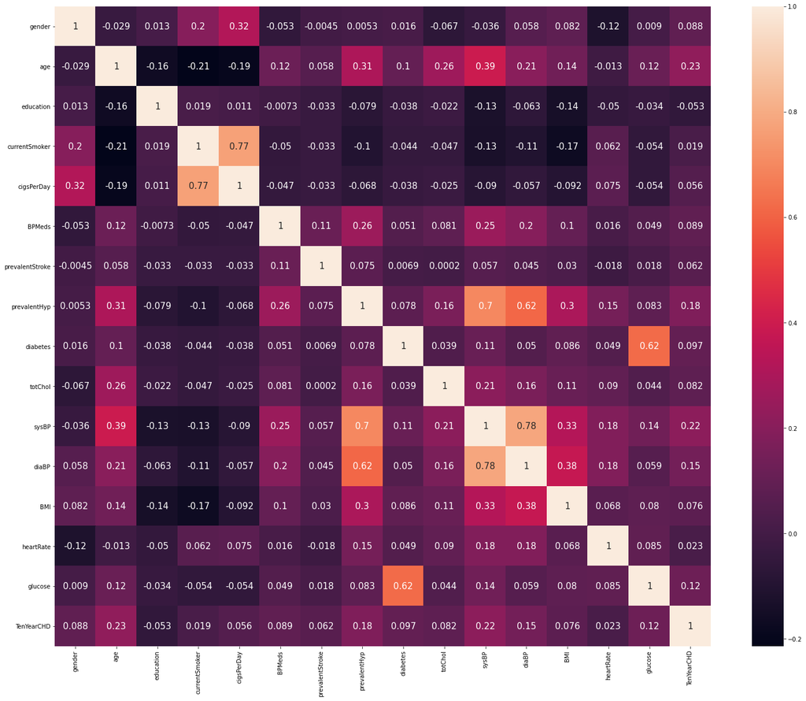

```python
plt.figure(figsize=(25, 20))
sns.heatmap(df.corr(), annot=True, annot_kws={"size": 15})

plt.show()
```

# Models Development

### Importing Libraries

```python
from sklearn.preprocessing import StandardScaler
from imblearn.over_sampling import RandomOverSampler
from imblearn.under_sampling import RandomUnderSampler
from imblearn.pipeline import Pipeline
from sklearn.ensemble import ExtraTreesClassifier
from sklearn.model_selection import train_test_split
```

```python
X = df.drop('TenYearCHD',axis=1)         # the features
y = df['TenYearCHD']                     # the target
```

### Oversampling Data

```python
# Perform oversampling
oversample = RandomOverSampler(sampling_strategy='minority')
X_over, y_over = oversample.fit_resample(X, y)
```

### Train & Test Data Split

```python
# Split the data into train and test sets
X_train, X_test, y_train, y_test = train_test_split(X_over, y_over, test_size=0.2)
```

### Feature Scaling using Standardization

```python
# Perform standardization
scaler = StandardScaler()
X_train_scaled = scaler.fit_transform(X_train)
X_test_scaled = scaler.transform(X_test)
```

### Applying Extra Trees Classifier

```python
steps = [('model', ExtraTreesClassifier())]
pipeline = Pipeline(steps=steps)
```

### Fitting the data

```python
pipeline.fit(X_train_scaled, y_train)
```

```
Pipeline(steps=[('model', ExtraTreesClassifier())])
```

### Making Predictions on Test Data

```python
pipepred = pipeline.predict(X_test_scaled)
```

# Model Evaluation & Validation

### Importing Libraries

```python
from sklearn.metrics import classification_report, confusion_matrix, cohen_kappa_score, matthews_corrcoef, roc_auc_score, roc_curve
from sklearn.model_selection import cross_val_score, StratifiedKFold
```

### Classification Report & Confusion Matrix

```
              precision    recall  f1-score   support

           0       0.99      0.98      0.99       727
           1       0.98      0.99      0.99       711

    accuracy                           0.99      1438
   macro avg       0.99      0.99      0.99      1438
weighted avg       0.99      0.99      0.99      1438
```

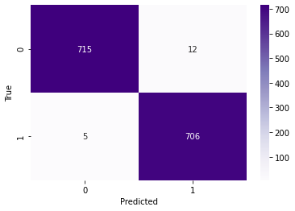

```python
# Accuracy, precision, recall, and f1-score
print(classification_report(y_test, pipepred))

# Confusion Matrix
cm = confusion_matrix(y_test, pipepred)

# Plot confusion matrix
sns.heatmap(cm, annot=True, fmt='d', cmap="Purples")
plt.xlabel('Predicted')
plt.ylabel('True')
plt.show()
```

### AUC & ROC Curve

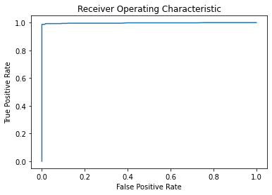

```
AUC: 0.997
```

```python
# Calculate AUC
probas = pipeline.predict_proba(X_test_scaled)
auc = roc_auc_score(y_test, probas[:, 1])

# Calculate ROC curve
fpr, tpr, thresholds = roc_curve(y_test, probas[:, 1])

# Plot ROC curve
plt.plot(fpr, tpr)
plt.title('Receiver Operating Characteristic')
plt.xlabel('False Positive Rate')
plt.ylabel('True Positive Rate')
plt.show()

print("AUC:", round(auc, 3))
```

### Cross Validation

```python
# Cross-Validation test
scores = cross_val_score(pipeline, X_over, y_over, cv=5, scoring='accuracy')

# Print the cross-validation scores
print("Cross-Validation Scores:", np.round(scores, 3))
print("Mean Accuracy:", round(np.mean(scores), 2))

# Stratified k-fold cross-validation
skf = StratifiedKFold(n_splits=5, shuffle=True, random_state=42)
cv_scores = cross_val_score(pipeline, X_over, y_over, cv=skf, scoring='accuracy')

print("Stratified k-fold Cross-Validation Scores:", np.round(cv_scores, 3))
print("Mean Accuracy:", round(cv_scores.mean(), 3))

# Nested cross-validation
nested_scores = cross_val_score(pipeline, X_over, y_over, cv=skf, scoring='accuracy')

print("Nested Cross-Validation Scores:", np.round(nested_scores, 3))
print("Mean Accuracy:", round(nested_scores.mean(), 3))
```

```
Cross-Validation Scores: [0.989 0.987 0.997 0.993 0.992]
Mean Accuracy: 0.99
Stratified k-fold Cross-Validation Scores: [0.987 0.984 0.986 0.989 0.985]
Mean Accuracy: 0.986
Nested Cross-Validation Scores: [0.988 0.981 0.987 0.99  0.985]
Mean Accuracy: 0.986
```

### Kappa & MCC

```python
# Calculate Kappa
kappa = cohen_kappa_score(y_test, pipepred)

# Calculate Matthews Correlation Coefficient (MCC)
mcc = matthews_corrcoef(y_test, pipepred)

print("Kappa:", round(kappa, 3))
print("MCC:", round(mcc, 3))
```

```
Kappa: 0.976
MCC: 0.976
```